# Anaylysis Process for MSc Dissertation

PSY6009_200256720_Webster

September 2021

The repo for this analysis process are available online via Github, please click [here](https://github.com/wxzhao17/nocebo).

# **1 Introduction**

## 1.1 Background

*MSc Dissertation*

It is the analysis part for the MSc dissertation *The Nocebo effect in the COVID-19 Pandemic: the role of information spreading*.

The aims of this research are

1. identify the nocebo effect in the COVID-19 pandemic and examine the effect of information spreading on nocebo response to COVID-19;
2. conduct a quantitative study to give empirical evidence supporting the theoretical framework from Amanzio et al. (2020);
3. provide some applicable suggestions and measures to minimise the nocebo effect in the pandemic.

*Programming environment*

- Software environment: [R](https://www.r-project.org/) version 4.1.0

## 1.2 Data Origin

The data used in this study was from the longitudinal survey via Internet across 4 waves of the COVID-19 psychological research consortium (C19PRC) study. Details see Figure below.

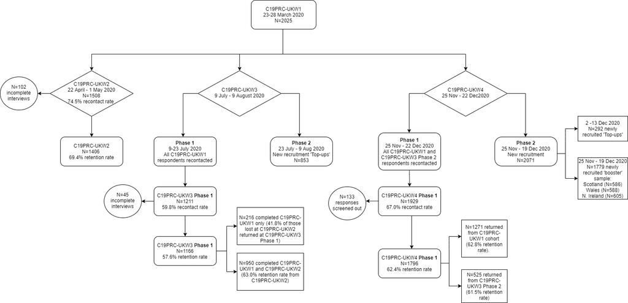

## 1.3 Hypothses

- H1: People who know more information about COVID-19 will have higher COVID-19 anxiety and be more likely to have a nocebo response to COVID-19.
- H2: People who have higher anxiety to COVID will be more likely to have a nocebo response to COVID-19.
- H3: When both know the same amount of information about COVID-19, compared to people who trust little in information sources, people who trust much in information sources will have higher COVID-19 anxiety and be more likely to have a nocebo response to COVID-19.
- H4: People who know more information about COVID-19 from non-authority sources than authority sources will have higher COVID-19 anxiety and be more likely to have a nocebo response to COVID-19.

# **2 Data Preparations**

## 2.1 load the data

```r
# help to manage the data
library(tidyverse)
```

```r
# use the packages to load the original data
# load the original data and name it as "nocebo_0"
nocebo_0<- read.csv(here("data","COVID W1_W2_W3_W4 Cleaned 4949.csv"))

# check the numbers of observations and variables
dim(nocebo_0)
```

```
## [1] 4949 1960
```

```r
# check the first 5 rows and 5 columns of the original data "nocebo_0"
head(nocebo_0)[1:5]
```

```
##   锘縉ew_PID W1_Present W2_Present W3Re_Present W3Top_Present
## 1 1066953349         NA         NA           NA            NA
## 2 1067382320         NA         NA           NA             1
## 3 1067415527         NA         NA           NA            NA
## 4 1067992883          1          1            1            NA
## 5 1072329704          1          1            1            NA
## 6 1072424110         NA         NA           NA            NA
```

```r
# there is an error in the name of the first column, rename and check it again
colnames(nocebo_0)[1] = "New_PID"

# check the first 5 rows and 5 columns of the data
head(nocebo_0)[1:5]
```

```
##      New_PID W1_Present W2_Present W3Re_Present W3Top_Present
## 1 1066953349         NA         NA           NA            NA
## 2 1067382320         NA         NA           NA             1
## 3 1067415527         NA         NA           NA            NA
## 4 1067992883          1          1            1            NA
## 5 1072329704          1          1            1            NA
## 6 1072424110         NA         NA           NA            NA
```

## 2.2 Select the sample and recode the variables

Firstly, I select variables used in this research and the qualified participants presented in wave 1 and wave 3 recontacts.And I recode and rename the variables.

```r
# sample from wave 1 and wave 3 recontacts
# save these data with the name of "df1"
df1<- nocebo_0 %>%
  # select the variables
  select(
    # unique ID of every participant
    New_PID,

    # participants in wave 3 recontacts
    W3Re_Present,

    # Sourcing of information measured in wave 1
    W1_INFO_1, W1_INFO_2, W1_INFO_3, W1_INFO_4,
    W1_INFO_5, W1_INFO_6, W1_INFO_7, W1_INFO_8,W1_INFO_9,

    # Level of trust in information source measured in wave 1
    W1_TRUST_1, W1_TRUST_2, W1_TRUST_3, W1_TRUST_4,
    W1_TRUST_5, W1_TRUST_6, W1_TRUST_7, W1_TRUST_8, W1_TRUST_9,

    # Anxiety-level relating to COVID-19 in wave 1
    W1_COVID19_anxiety,

    # Experience of being infected with COVID-19 (self) in wave 3
    W3_C19_Infected, W3_Infected_Unsure, W3_Infected_Yes,

    # control variables
    W3_Age_year, W3_Age_categories, W3_Gender_binary, W1_Income_2019,
    W1_Dx_health_preC19, W3_GAD_Cat,
    W3_GAD_1, W3_GAD_2, W3_GAD_3, W3_GAD_4,
    W3_GAD_5, W3_GAD_6, W3_GAD_7) %>%

  # select the qualified participants
  filter(
    # select the participants presented in wave 1 and wave 3
    W3Re_Present == "1" &

    # select those having subjective judgment of COVID-19 infection
    W3_C19_Infected >= "1" & W3_Infected_Yes < "2") %>%

  # recode the variables
  mutate(
    # "source" represent the source of the sample
    source = ifelse(W3Re_Present == "1", 1),

    # "sub_infected" represent the nocebo response to COVID-19
    # "0" = Subjectively thought they have not had COVID-19, "1" = Subjectively thought they have had COVID-19
    sub_infected = ifelse(W3_Infected_Unsure == "1", 0, 1),

    # "health" represent the healthy problem
    # Due to the scale of this item measured in wave 1 is different to those measured in wave 3 and 4, recode it and keep the scale consistent.
    # "0" = No, "1" = Yes
    health = ifelse(W1_Dx_health_preC19 == "2", 0, 1),

    # "gender" represent the gender binary
    # recode gender into 0/1, which is convenient for the analysis.
    # "0"= male, "1" = female
    gender = ifelse(W3_Gender_binary == "1", 0, 1)) %>%

  # rename the variables
  rename(
    id = New_PID ,

    info_1 = W1_INFO_1, info_2 = W1_INFO_2, info_3 = W1_INFO_3,
    info_4 = W1_INFO_4, info_5 = W1_INFO_5, info_6 = W1_INFO_6,
    info_7 = W1_INFO_7, info_8 = W1_INFO_8, info_9 = W1_INFO_9,

    trust_1 = W1_TRUST_1, trust_2 = W1_TRUST_2, trust_3 = W1_TRUST_3,
    trust_4 = W1_TRUST_4, trust_5 = W1_TRUST_5, trust_6 = W1_TRUST_6,
    trust_7 = W1_TRUST_7, trust_8 = W1_TRUST_8, trust_9 = W1_TRUST_9,

    c19_anxiety = W1_COVID19_anxiety,

    age_year = W3_Age_year, age_cate = W3_Age_categories,
    income = W1_Income_2019, gad = W3_GAD_Cat,
    gad_1 = W3_GAD_1, gad_2 = W3_GAD_2, gad_3 = W3_GAD_3,
    gad_4 = W3_GAD_4, gad_5 = W3_GAD_5, gad_6 = W3_GAD_6, gad_7 = W3_GAD_7)


# check the numbers of observations and variables
dim(df1)
```

```
## [1] 138  41
```

```r
# randomly check the 5 rows of df1
sample_n(df1, 5)
```

```
##           id W3Re_Present info_1 info_2 info_3 info_4 info_5 info_6 info_7
## 1 1490648509            1      1      4      3      3      2      1      3
## 2 1491514367            1      2      3      2      2      2      1      1
## 3 1490578373            1      4      4      4      4      1      1      4
## 4 1490695636            1      2      4      2      4      1      1      1
## 5 1491629097            1      1      3      4      3      3      1      2
##   info_8 info_9 trust_1 trust_2 trust_3 trust_4 trust_5 trust_6 trust_7 trust_8
## 1      3      2       2       3       3       2       1       4       4       3
## 2      1      2       3       3       3       2       1       3       3       2
## 3      2      2       2       4       3       4       1       4       4       2
## 4      2      3       2       3       2       2       1       3       3       3
## 5      4      2       1       2       3       2       2       4       4       4
##   trust_9 c19_anxiety W3_C19_Infected W3_Infected_Unsure W3_Infected_Yes
## 1       3          76               2                  3              -9
## 2       3          65               2                  3              -9
## 3       2          71               1                 -9               1
## 4       2          92               2                  3              -9
## 5       3         100               2                  1              -9
##   age_year age_cate W3_Gender_binary income W1_Dx_health_preC19 gad gad_1 gad_2
## 1       54        4                1      4                   2   1     1     1
## 2       53        4                2      4                   2   0     1     1
## 3       35        3                2      5                   2   0     0     0
## 4       62        5                1      4                   2   0     0     0
## 5       47        4                2      3                   2   0     1     1
##   gad_3 gad_4 gad_5 gad_6 gad_7 source sub_infected health gender
## 1     2     1     1     2     2      1            1      0      0
## 2     1     1     1     2     1      1            1      0      1
## 3     0     0     0     0     0      1            1      0      1
## 4     0     2     0     1     0      1            1      0      0
## 5     1     1     0     0     1      1            0      0      1
```

Next, I repeat this process to select the qualified participants in wave 3 top-ups, wave 4 top-ups and boosters, respectively.

```r
# sample from wave 3 top-ups
# save these data with the name of "df2"
df2<- nocebo_0 %>%
  # select the variables
  select(
    # unique ID of every participant
    New_PID,

    # participants in wave 3 top-ups
    W3Top_Present,

    # Sourcing of information measured in wave 3
    W3_INFO_1, W3_INFO_2, W3_INFO_3, W3_INFO_4,
    W3_INFO_5, W3_INFO_6, W3_INFO_7, W3_INFO_8, W3_INFO_9,

    # Level of trust in information source measured in wave 3
    W3_TRUST_1, W3_TRUST_2, W3_TRUST_3, W3_TRUST_4,
    W3_TRUST_5, W3_TRUST_6, W3_TRUST_7, W3_TRUST_8, W3_TRUST_9,

    # Anxiety-level relating to COVID-19 in wave 3
    W3_COVID19_anxiety,

    # Experience of being infected with COVID-19 (self) in wave 3
    W3_C19_Infected, W3_Infected_Unsure, W3_Infected_Yes,

    # control variables
    W3_Age_year, W3_Age_categories, W3_Gender_binary, IW3_ncome_2019,
    W3_Chronic_illness_self, W3_GAD_Cat,
    W3_GAD_1, W3_GAD_2, W3_GAD_3, W3_GAD_4,
    W3_GAD_5, W3_GAD_6, W3_GAD_7) %>%

  # select the qualified participants
  filter(
    # select the participants presented in wave 3 top-ups
    W3Top_Present == "1" &

    # select those having subjective judgment of COVID-19 infection
    W3_C19_Infected >= "1" & W3_Infected_Yes < "2") %>%

  # recode the variables
  mutate(
    # "source" represent the source of the sample
    source = ifelse(W3Top_Present == "1", 2),

    # "sub_infected" represent the nocebo response to COVID-19
    # "0" = Subjectively thought they have not had COVID-19, "1" = Subjectively thought they have had COVID-19
    sub_infected = ifelse(W3_Infected_Unsure == "1", 0, 1),

    # "gender" represent the gender binary
    # recode gender into 0/1, which is convenient for the analysis.
    # "0"= male, "1" = female
    gender = ifelse(W3_Gender_binary == "1", 0, 1)) %>%

  # rename the variables
  rename(
    id = New_PID ,

    info_1 = W3_INFO_1, info_2 = W3_INFO_2, info_3 = W3_INFO_3,
    info_4 = W3_INFO_4, info_5 = W3_INFO_5, info_6 = W3_INFO_6,
    info_7 = W3_INFO_7, info_8 = W3_INFO_8, info_9 = W3_INFO_9,

    trust_1 = W3_TRUST_1, trust_2 = W3_TRUST_2, trust_3 = W3_TRUST_3,
    trust_4 = W3_TRUST_4, trust_5 = W3_TRUST_5, trust_6 = W3_TRUST_6,
    trust_7 = W3_TRUST_7, trust_8 = W3_TRUST_8, trust_9 = W3_TRUST_9,

    c19_anxiety = W3_COVID19_anxiety,

    age_year = W3_Age_year, age_cate = W3_Age_categories, income = IW3_ncome_2019,
    gad = W3_GAD_Cat, health = W3_Chronic_illness_self,
    gad_1 = W3_GAD_1, gad_2 = W3_GAD_2, gad_3 = W3_GAD_3,
    gad_4 = W3_GAD_4, gad_5 = W3_GAD_5, gad_6 = W3_GAD_6, gad_7 = W3_GAD_7)


# check the numbers of observations and variables
dim(df2)
```

```
## [1] 112  40
```

```r
# randomly check the 5 rows of df2
sample_n(df2, 5)
```

```
##           id W3Top_Present info_1 info_2 info_3 info_4 info_5 info_6 info_7
## 1 1490761469             1      1      3      2      3      1      1      1
## 2 1736200782             1      3      3      4      4      3      4      3
## 3 1350225724             1      1      2      2      3      3      1      1
## 4 1491410502             1      1      1      1      3      3      2      2
## 5 1491455304             1      2      2      4      3      2      1      3
##   info_8 info_9 trust_1 trust_2 trust_3 trust_4 trust_5 trust_6 trust_7 trust_8
## 1      1      1       1       1       3       2       1       3       1       1
## 2      3      2       2       4       3       3       3       2       2       4
## 3      1      2       2       2       2       2       2       2       2       2
## 4      1      4       1       1       2       3       3       3       3       2
## 5      4      3       2       3       3       3       2       4       4       1
##   trust_9 c19_anxiety W3_C19_Infected W3_Infected_Unsure W3_Infected_Yes
## 1       3         100               2                  1              -9
## 2       4          51               2                  3              -9
## 3       2          30               2                  3              -9
## 4       3          56               2                  1              -9
## 5       1          26               2                  1              -9
##   age_year age_cate W3_Gender_binary income health gad gad_1 gad_2 gad_3 gad_4
## 1       48        4                1      1      1   1     0     2     2     2
## 2       26        2                2      1      1   0     1     1     1     1
## 3       29        2                2      2      0   0     2     1     1     1
## 4       33        2                2      1      0   1     3     3     3     3
## 5       23        1                1      1      1   1     2     1     3     2
##   gad_5 gad_6 gad_7 source sub_infected gender
## 1     2     2     3      2            0      0
## 2     1     1     1      2            1      1
## 3     0     2     1      2            1      1
## 4     2     2     2      2            0      1
## 5     2     1     1      2            0      0
```

```r
# sample from wave 4 top-ups and boosters
# save these data with the name of "df3"
df3<- nocebo_0 %>%
  # select the variables
  select(
    # unique ID of every participant
    New_PID,

    # participants in wave 4
    W4_Type,

    # Sourcing of information measured in wave 4
    W4_INFO_1, W4_INFO_2, W4_INFO_3, W4_INFO_4,
    W4_INFO_5, W4_INFO_6, W4_INFO_7, W4_INFO_8, W4_INFO_9,

    # Level of trust in information source measured in wave 4
    W4_TRUST_1, W4_TRUST_2, W4_TRUST_3, W4_TRUST_4,
    W4_TRUST_5, W4_TRUST_6, W4_TRUST_7, W4_TRUST_8, W4_TRUST_9,

    # Anxiety-level relating to COVID-19 in wave 4
    W4_COVID19_anxiety,

    # Experience of being infected with COVID-19 (self) in wave 4
    W4_C19_Infected, W4_Infected_Unsure, W4_Infected_Yes,

    # control variables
    W4_Age_year, W4_Age_categories, W4_Gender_binary, W4_Income_2019,
    W4_Chronic_illness_self, W4_GAD_Cat,
    W4_GAD1, W4_GAD2, W4_GAD3, W4_GAD4,
    W4_GAD5, W4_GAD6, W4_GAD7) %>%

  # select the qualified participants
  filter(
    # select the participants presented in wave 4 top-ups and boosters
    W4_Type >= "2" &

    # select those having subjective judgment of COVID-19 infection
    W4_C19_Infected >= "1" & W4_Infected_Yes < "2") %>%

  # recode the variables
  mutate(
    # "source" represent the source of the sample
    source = ifelse(W4_Type == "2", 3,4),

    # "sub_infected" represent the nocebo response to COVID-19
    # "0" = Subjectively thought they have not had COVID-19, "1" = Subjectively thought they have had COVID-19
    sub_infected = ifelse(W4_Infected_Unsure == "1", 0, 1),

    # "gender" represent the gender binary
    # recode gender into 0/1, which is convenient for the analysis.
    # "0"= male, "1" = female
    gender = ifelse(W4_Gender_binary == "1", 0, 1)) %>%

  # rename the variables
  rename(
    id = New_PID ,

    info_1 = W4_INFO_1, info_2 = W4_INFO_2, info_3 = W4_INFO_3,
    info_4 = W4_INFO_4, info_5 = W4_INFO_5, info_6 = W4_INFO_6,
    info_7 = W4_INFO_7, info_8 = W4_INFO_8, info_9 = W4_INFO_9,

    trust_1 = W4_TRUST_1, trust_2 = W4_TRUST_2, trust_3 = W4_TRUST_3,
    trust_4 = W4_TRUST_4, trust_5 = W4_TRUST_5, trust_6 = W4_TRUST_6,
    trust_7 = W4_TRUST_7, trust_8 = W4_TRUST_8, trust_9 = W4_TRUST_9,

    c19_anxiety = W4_COVID19_anxiety,

    age_year = W4_Age_year, age_cate = W4_Age_categories, income = W4_Income_2019,
    gad = W4_GAD_Cat, health = W4_Chronic_illness_self,
    gad_1 = W4_GAD1, gad_2 = W4_GAD2, gad_3 = W4_GAD3,
    gad_4 = W4_GAD4, gad_5 = W4_GAD5, gad_6 = W4_GAD6, gad_7 = W4_GAD7)


# check the numbers of observations and variables
dim(df3)
```

```
## [1] 224  40
```

```r
# randomly check the 5 rows of df3
sample_n(df3, 5)
```

```
##           id W4_Type info_1 info_2 info_3 info_4 info_5 info_6 info_7 info_8
## 1 1490762018       2      3      4      4      2      1      1      1      1
## 2 1839040725       3      1      1      1      1      2      2      2      3
## 3 1830567958       2      1      2      3      4      3      2      2      1
## 4 1849250921       2      1      2      1      3      3      1      1      1
## 5 1848115626       2      2      2      2      4      4      2      4      1
##   info_9 trust_1 trust_2 trust_3 trust_4 trust_5 trust_6 trust_7 trust_8
## 1      2       4       4       4       2       1       1       1       1
## 2      4       2       2       2       3       3       3       4       4
## 3      2       1       2       3       4       3       2       2       3
## 4      4       2       2       2       2       1       3       3       2
## 5      4       2       2       2       2       2       3       3       2
##   trust_9 c19_anxiety W4_C19_Infected W4_Infected_Unsure W4_Infected_Yes
## 1       2          71               1                 -9               1
## 2       4          76               1                 -9               1
## 3       4          44               1                 -9               1
## 4       3           4               2                  1              -9
## 5       2          75               2                  3              -9
##   age_year age_cate W4_Gender_binary income health gad gad_1 gad_2 gad_3 gad_4
## 1       31        2                2      2      1   1     2     2     2     2
## 2       21        1                1      4      1   0     0     1     2     3
## 3       26        2                1      3      1   0     1     0     3     2
## 4       28        2                1      2      0   0     0     1     1     0
## 5       34        2                2      2      0   0     1     0     0     0
##   gad_5 gad_6 gad_7 source sub_infected gender
## 1     2     2     2      3            1      1
## 2     2     1     0      4            1      0
## 3     1     0     1      3            1      0
## 4     0     1     0      3            0      0
## 5     0     0     0      3            1      1
```

## 2.3 Synthesize the data

```r
# first remove the redundant variables and keep the same numbers and names of variables of every dataset
df1 <- df1 %>%
  select(-W3Re_Present, -W3_C19_Infected, -W3_Infected_Unsure,
         -W3_Infected_Yes, -W3_Gender_binary, -W1_Dx_health_preC19)

df2 <- df2 %>%
  select(-W3Top_Present, -W3_C19_Infected, -W3_Infected_Unsure,
         -W3_Infected_Yes, -W3_Gender_binary)

df3 <- df3 %>%
  select(-W4_Type, -W4_C19_Infected, -W4_Infected_Unsure,
         -W4_Infected_Yes, -W4_Gender_binary)

# synthesize 3 datasets into one and name it as "nocebo_1"
nocebo_1 <- rbind(df1,df2,df3)

# check the numbers of observations and variables
dim(nocebo_1)
```

```
## [1] 474  35
```

```r
# randomly check the 5 rows of nocebo_1
sample_n(nocebo_1,5)
```

```
##                                                                 id info_1
## 1                                                       1490958930      3
## 2 NTZlOWRlY2YtNWQwMS0yODg2LTY3Y2YtZTljMjgzMDNjYzE1M2EtMTYzMDE4Njk-      1
## 3 NTUyZGUxNDctN2Q2ZC1iNzk0LTU2NDYtZDYwNjBhYWVkOGIyM2EtMTYzMDE4Njk-      3
## 4                                                       1491781830      4
## 5                                                       1490755629      4
##   info_2 info_3 info_4 info_5 info_6 info_7 info_8 info_9 trust_1 trust_2
## 1      4      2      3      3      1      1      3      3       2       2
## 2      4      1      2      1      1      1      2      2       1       3
## 3      3      3      3      2      2      2      2      2       3       3
## 4      4      4      4      3      1      1      1      3       2       2
## 5      3      3      2      2      1      1      3      1       4       4
##   trust_3 trust_4 trust_5 trust_6 trust_7 trust_8 trust_9 c19_anxiety age_year
## 1       2       2       2       1       1       2       2          71       22
## 2       1       1       1       3       3       1       3          68       72
## 3       3       3       3       3       3       2       2          50       61
## 4       2       2       3       2       2       1       2          10       77
## 5       4       2       2       4       4       3       2          60       71
##   age_cate income gad gad_1 gad_2 gad_3 gad_4 gad_5 gad_6 gad_7 source
## 1        1      2   0     1     1     1     1     1     1     1      3
## 2        6      1   0     0     0     0     0     0     0     0      4
## 3        5      4   0     0     0     0     0     0     0     0      4
## 4        6      5   0     0     0     0     0     0     0     0      1
## 5        6      3   0     0     0     0     0     0     0     0      4
##   sub_infected health gender
## 1            1      0      1
## 2            0      1      0
## 3            0      0      0
## 4            1      0      1
## 5            1      0      0
```

```r
# check the characteristics of participants from different waves
nocebo_1 %>%
  group_by(source) %>%
  summarise(n = list(source),meanage = mean(age_year), sdage = sd(age_year), gender = mean(gender))
```

```
## # A tibble: 4 x 5
##   source n           meanage sdage gender
##    <dbl> <list>        <dbl> <dbl>  <dbl>
## 1      1 <dbl [138]>    47.8  14.5  0.478
## 2      2 <dbl [112]>    38.1  13.9  0.571
## 3      3 <dbl [55]>     30.8  10.3  0.636
## 4      4 <dbl [169]>    45.3  16.5  0.538
```

```r
# check the characteristics of the total sample
table(mean(nocebo_1$age_year),sd(nocebo_1$age_year), mean(nocebo_1$gender))
```

```
## , ,  = 0.540084388185654
##
##
##                    15.6980397793163
##   42.6708860759494                1
```

## 2.4 Reliability analysis

```r
# load the packages
library(psych)
```

```r
# select the items measured "Sourcing of information"
df4 <- nocebo_1 %>%
  select(info_1, info_2, info_3, info_4, info_5, info_6, info_7, info_8, info_9)

# calculate the Cronbach's alpha of "Sourcing of information"
alpha(df4, check.keys=TRUE)
```

```
##
## Reliability analysis
## Call: alpha(x = df4, check.keys = TRUE)
##
##   raw_alpha std.alpha G6(smc) average_r S/N   ase mean   sd median_r
##       0.75      0.75    0.77      0.25   3 0.017  2.3 0.58     0.23
##
##  lower alpha upper     95% confidence boundaries
## 0.71 0.75 0.78
##
##  Reliability if an item is dropped:
##        raw_alpha std.alpha G6(smc) average_r S/N alpha se var.r med.r
## info_1      0.73      0.74    0.76      0.26 2.8    0.019 0.022  0.25
## info_2      0.76      0.76    0.77      0.28 3.2    0.017 0.014  0.26
## info_3      0.72      0.73    0.75      0.25 2.7    0.019 0.023  0.23
## info_4      0.73      0.73    0.75      0.25 2.7    0.019 0.020  0.24
## info_5      0.72      0.72    0.74      0.25 2.6    0.019 0.017  0.23
## info_6      0.72      0.72    0.72      0.24 2.6    0.020 0.013  0.23
## info_7      0.71      0.71    0.72      0.23 2.4    0.020 0.015  0.23
## info_8      0.72      0.72    0.75      0.24 2.6    0.020 0.022  0.23
## info_9      0.71      0.72    0.74      0.24 2.5    0.020 0.019  0.23
##
##  Item statistics
##          n raw.r std.r r.cor r.drop mean   sd
## info_1 474  0.53  0.53  0.42   0.37  2.1 1.03
## info_2 474  0.40  0.39  0.27   0.22  3.1 0.99
## info_3 474  0.59  0.58  0.49   0.43  2.3 1.07
## info_4 474  0.57  0.57  0.49   0.42  2.8 0.99
## info_5 474  0.60  0.59  0.53   0.44  2.3 1.08
## info_6 474  0.60  0.61  0.59   0.47  1.6 0.94
## info_7 474  0.66  0.67  0.65   0.54  1.9 0.97
## info_8 474  0.61  0.62  0.54   0.47  2.4 1.01
## info_9 474  0.62  0.64  0.57   0.50  2.3 0.91
##
## Non missing response frequency for each item
##           1    2    3    4 miss
## info_1 0.38 0.28 0.23 0.11    0
## info_2 0.08 0.22 0.26 0.45    0
## info_3 0.30 0.23 0.31 0.16    0
## info_4 0.12 0.27 0.32 0.28    0
## info_5 0.31 0.26 0.25 0.18    0
## info_6 0.64 0.16 0.15 0.06    0
## info_7 0.46 0.28 0.18 0.08    0
## info_8 0.24 0.28 0.33 0.15    0
## info_9 0.19 0.40 0.30 0.11    0
```

```r
# select the items measured "Level of trust in information source"
df5 <- nocebo_1 %>%
  select(trust_1, trust_2, trust_3, trust_4, trust_5, trust_6, trust_7, trust_8, trust_9)

# calculate the Cronbach's alpha of "Level of trust in information source"
alpha(df5, check.keys=TRUE)
```

```
##
## Reliability analysis
## Call: alpha(x = df5, check.keys = TRUE)
##
##   raw_alpha std.alpha G6(smc) average_r S/N   ase mean   sd median_r
##       0.85      0.85    0.89      0.39 5.6 0.011  2.5 0.61     0.37
##
##  lower alpha upper     95% confidence boundaries
## 0.83 0.85 0.87
##
##  Reliability if an item is dropped:
##         raw_alpha std.alpha G6(smc) average_r S/N alpha se var.r med.r
## trust_1      0.83      0.83    0.87      0.38 4.9    0.012 0.029  0.37
## trust_2      0.83      0.83    0.86      0.37 4.7    0.012 0.025  0.35
## trust_3      0.82      0.82    0.86      0.36 4.6    0.013 0.025  0.35
## trust_4      0.84      0.84    0.87      0.39 5.2    0.011 0.029  0.40
## trust_5      0.85      0.85    0.88      0.42 5.7    0.010 0.021  0.41
## trust_6      0.83      0.83    0.86      0.39 5.0    0.012 0.021  0.37
## trust_7      0.83      0.83    0.86      0.39 5.1    0.012 0.021  0.38
## trust_8      0.83      0.83    0.87      0.38 4.8    0.012 0.031  0.35
## trust_9      0.84      0.84    0.88      0.40 5.3    0.011 0.033  0.41
##
##  Item statistics
##           n raw.r std.r r.cor r.drop mean   sd
## trust_1 474  0.70  0.70  0.65   0.60  2.2 0.93
## trust_2 474  0.74  0.74  0.72   0.65  2.6 0.93
## trust_3 474  0.78  0.78  0.77   0.70  2.5 0.89
## trust_4 474  0.63  0.64  0.59   0.53  2.3 0.82
## trust_5 474  0.52  0.53  0.46   0.38  1.9 0.91
## trust_6 474  0.69  0.67  0.66   0.58  3.0 0.96
## trust_7 474  0.68  0.67  0.66   0.57  3.0 0.96
## trust_8 474  0.72  0.71  0.66   0.62  2.6 0.95
## trust_9 474  0.61  0.62  0.54   0.50  2.5 0.84
##
## Non missing response frequency for each item
##            1    2    3    4 miss
## trust_1 0.25 0.36 0.30 0.09    0
## trust_2 0.13 0.31 0.38 0.18    0
## trust_3 0.12 0.36 0.37 0.15    0
## trust_4 0.18 0.42 0.35 0.06    0
## trust_5 0.42 0.32 0.21 0.05    0
## trust_6 0.09 0.17 0.35 0.39    0
## trust_7 0.08 0.20 0.32 0.40    0
## trust_8 0.16 0.29 0.38 0.17    0
## trust_9 0.11 0.41 0.36 0.12    0
```

```r
# select the items measured "Generalized Anxiety Disorder"
df6 <- nocebo_1 %>%
  select(gad_1, gad_2, gad_3, gad_4, gad_5, gad_6, gad_7)

# calculate the Cronbach's alpha of "Generalized Anxiety Disorder"
alpha(df6, check.keys=TRUE)
```

```
##
## Reliability analysis
## Call: alpha(x = df6, check.keys = TRUE)
##
##   raw_alpha std.alpha G6(smc) average_r S/N   ase mean   sd median_r
##       0.94      0.94    0.94       0.7  16 0.004 0.98 0.87     0.66
##
##  lower alpha upper     95% confidence boundaries
## 0.93 0.94 0.95
##
##  Reliability if an item is dropped:
##       raw_alpha std.alpha G6(smc) average_r S/N alpha se  var.r med.r
## gad_1      0.93      0.93    0.93      0.69  14   0.0048 0.0042  0.66
## gad_2      0.93      0.93    0.92      0.68  13   0.0051 0.0033  0.66
## gad_3      0.93      0.93    0.92      0.69  13   0.0050 0.0034  0.66
## gad_4      0.93      0.93    0.93      0.70  14   0.0048 0.0057  0.66
## gad_5      0.94      0.94    0.93      0.72  16   0.0043 0.0040  0.74
## gad_6      0.94      0.94    0.93      0.72  15   0.0043 0.0049  0.74
## gad_7      0.93      0.93    0.93      0.70  14   0.0046 0.0052  0.66
##
##  Item statistics
##         n raw.r std.r r.cor r.drop mean   sd
## gad_1 474  0.88  0.88  0.86   0.83 1.05 1.00
## gad_2 474  0.91  0.91  0.90   0.87 0.95 1.04
## gad_3 474  0.90  0.90  0.89   0.86 1.11 1.06
## gad_4 474  0.87  0.87  0.85   0.82 1.05 1.05
## gad_5 474  0.80  0.81  0.76   0.73 0.75 0.94
## gad_6 474  0.81  0.81  0.76   0.74 1.10 1.00
## gad_7 474  0.86  0.86  0.83   0.80 0.88 0.98
##
## Non missing response frequency for each item
##          0    1    2    3 miss
## gad_1 0.37 0.32 0.20 0.11    0
## gad_2 0.44 0.28 0.16 0.12    0
## gad_3 0.36 0.32 0.17 0.15    0
## gad_4 0.38 0.31 0.17 0.14    0
## gad_5 0.54 0.25 0.15 0.07    0
## gad_6 0.34 0.33 0.21 0.11    0
## gad_7 0.47 0.26 0.19 0.08    0
```

## 2.5 Calculate the variables

```r
# rescale the item of "anxiety to COVID-19" to range from 0 to 1
nocebo_1$c19_anxiety = nocebo_1$c19_anxiety*0.01

# calculate the sum of knowing information about COVID-19 and trust in information sources
nocebo_1$total_info = apply(nocebo_1[,2:10],1,sum)

nocebo_1$total_trust = apply(nocebo_1[,11:19],1,sum)
```

## 2.6 Data description

```r
# reorder the columns
nocebo_1 <- nocebo_1 %>%
  select(id,
         info_1, info_2, info_3, info_4, info_5, info_6, info_7, info_8, info_9,
         trust_1, trust_2, trust_3, trust_4, trust_5, trust_6, trust_7, trust_8, trust_9,
         total_info,total_trust, c19_anxiety, sub_infected, source,
         age_year, age_cate, gender, income, health, gad,
         gad_1, gad_2, gad_3, gad_4, gad_5, gad_6, gad_7)

# randomly check the 5 rows of nocebo_2
sample_n(nocebo_1,5)
```

```
##                                                                 id info_1
## 1 NTk2MWY1ZTYtYTdiNC02YTI3LTUwZTctYzI0YTEwMjU3ZDExM2EtMTYzMDE4Njk-      2
## 2                                                       1742761486      3
## 3                                                       1491744861      1
## 4 YTY2MmNiM2QtYmQwNy04YWZhLTQ0M2MtZmM0OWY1YmE0N2M1M2EtMTYzMDE4Njk-      1
## 5                                                       1460013697      1
##   info_2 info_3 info_4 info_5 info_6 info_7 info_8 info_9 trust_1 trust_2
## 1      2      1      2      2      1      1      1      2       1       1
## 2      4      1      2      3      4      1      2      3       4       1
## 3      3      3      4      3      1      1      4      4       2       2
## 4      3      2      2      2      1      1      2      2       1       1
## 5      4      1      2      2      1      4      2      2       1       3
##   trust_3 trust_4 trust_5 trust_6 trust_7 trust_8 trust_9 total_info
## 1       1       1       1       2       2       1       2         14
## 2       2       1       2       3       4       1       2         23
## 3       2       2       2       3       3       2       3         24
## 4       1       1       1       2       2       2       2         16
## 5       3       2       2       3       4       3       2         19
##   total_trust c19_anxiety sub_infected source age_year age_cate gender income
## 1          12        0.55            1      4       46        4      1      1
## 2          20        0.49            0      3       23        1      1      1
## 3          21        0.08            1      2       47        4      1      5
## 4          13        0.29            1      4       55        5      1      1
## 5          23        0.81            1      4       44        3      1      3
##   health gad gad_1 gad_2 gad_3 gad_4 gad_5 gad_6 gad_7
## 1      0   1     2     3     2     2     2     3     2
## 2      0   0     0     1     2     3     0     1     2
## 3      1   1     3     3     3     3     3     2     1
## 4      1   0     0     0     0     0     0     1     0
## 5      1   0     1     1     1     1     1     1     0
```

[output not shown]

# **3 Preliminary Analysis**

## 3.1 Descriptive statistics

```r
# check the social-demographic characteristics of sample used in this analysis
# check the numbers of male and female
table(nocebo_1$gender)
```

```
##
##   0   1
## 218 256
```

```r
# check the proportion of each gender in the sample
prop.table(table(nocebo_1$gender))
```

```
##
##         0         1
## 0.4599156 0.5400844
```

```r
# check the numbers of each age group
table(nocebo_1$age_cate)
```

```
##
##   1   2   3   4   5   6
##  73 107  83  82  80  49
```

```r
# check the proportion of each age group in the sample
prop.table(table(nocebo_1$age_cate))
```

```
##
##         1         2         3         4         5         6
## 0.1540084 0.2257384 0.1751055 0.1729958 0.1687764 0.1033755
```

```r
# check the numbers of each income group
table(nocebo_1$income)
```

```
##
##   1   2   3   4   5
## 100  96 104  93  81
```

```r
# check the proportion of each income group in the sample
prop.table(table(nocebo_1$income))
```

```
##
##         1         2         3         4         5
## 0.2109705 0.2025316 0.2194093 0.1962025 0.1708861
```

```r
# description of the sample
describe(nocebo_1[,c(20:23,25:30)])
```

```
##              vars   n  mean    sd median trimmed   mad min max range  skew
## total_info      1 474 20.77  5.19  20.00   20.66  5.19   9  36    27  0.21
## total_trust     2 474 22.73  5.52  23.00   23.05  5.93   9  36    27 -0.43
## c19_anxiety     3 474  0.61  0.27   0.66    0.63  0.23   0   1     1 -0.56
## sub_infected    4 474  0.85  0.36   1.00    0.93  0.00   0   1     1 -1.91
## age_year        5 474 42.67 15.70  41.50   42.08 20.02  18  79    61  0.25
## age_cate        6 474  3.29  1.59   3.00    3.23  1.48   1   6     5  0.16
## gender          7 474  0.54  0.50   1.00    0.55  0.00   0   1     1 -0.16
## income          8 474  2.91  1.39   3.00    2.89  1.48   1   5     4  0.06
## health          9 474  0.38  0.49   0.00    0.35  0.00   0   1     1  0.49
## gad            10 474  0.33  0.47   0.00    0.29  0.00   0   1     1  0.71
##              kurtosis   se
## total_info      -0.16 0.24
## total_trust     -0.13 0.25
## c19_anxiety     -0.46 0.01
## sub_infected     1.66 0.02
## age_year        -1.02 0.72
## age_cate        -1.16 0.07
## gender          -1.98 0.02
## income          -1.25 0.06
## health          -1.76 0.02
## gad             -1.49 0.02
```

## 3.2 Correlation matrix

```r
# check the correlation matrix with the p-values
corr.test(nocebo_1[,c(20:23,25:30)])
```

```
## Call:corr.test(x = nocebo_1[, c(20:23, 25:30)])
## Correlation matrix
##              total_info total_trust c19_anxiety sub_infected age_year age_cate
## total_info         1.00        0.63        0.18         0.05    -0.09    -0.09
## total_trust        0.63        1.00        0.18         0.10    -0.01    -0.01
## c19_anxiety        0.18        0.18        1.00        -0.05     0.06     0.06
## sub_infected       0.05        0.10       -0.05         1.00    -0.10    -0.10
## age_year          -0.09       -0.01        0.06        -0.10     1.00     0.98
## age_cate          -0.09       -0.01        0.06        -0.10     0.98     1.00
## gender            -0.06       -0.02        0.14         0.06    -0.29    -0.29
## income             0.08        0.12       -0.06         0.11     0.03     0.03
## health             0.09        0.02       -0.08        -0.02    -0.01    -0.02
## gad                0.14       -0.01        0.18        -0.05    -0.27    -0.27
##              gender income health   gad
## total_info    -0.06   0.08   0.09  0.14
## total_trust   -0.02   0.12   0.02 -0.01
## c19_anxiety    0.14  -0.06  -0.08  0.18
## sub_infected   0.06   0.11  -0.02 -0.05
## age_year      -0.29   0.03  -0.01 -0.27
## age_cate      -0.29   0.03  -0.02 -0.27
## gender         1.00  -0.12  -0.05  0.11
## income        -0.12   1.00   0.00 -0.18
## health        -0.05   0.00   1.00  0.01
## gad            0.11  -0.18   0.01  1.00
## Sample Size
## [1] 474
## Probability values (Entries above the diagonal are adjusted for multiple tests.)
##              total_info total_trust c19_anxiety sub_infected age_year age_cate
## total_info         0.00        0.00        0.00         1.00     1.00     1.00
## total_trust        0.00        0.00        0.00         0.94     1.00     1.00
## c19_anxiety        0.00        0.00        0.00         1.00     1.00     1.00
## sub_infected       0.27        0.03        0.28         0.00     0.98     0.73
## age_year           0.06        0.83        0.20         0.04     0.00     0.00
## age_cate           0.05        0.78        0.20         0.03     0.00     0.00
## gender             0.23        0.61        0.00         0.17     0.00     0.00
## income             0.08        0.01        0.18         0.01     0.54     0.46
## health             0.06        0.61        0.07         0.74     0.78     0.65
## gad                0.00        0.88        0.00         0.30     0.00     0.00
##              gender income health  gad
## total_info     1.00   1.00   1.00 0.09
## total_trust    1.00   0.27   1.00 1.00
## c19_anxiety    0.09   1.00   1.00 0.00
## sub_infected   1.00   0.44   1.00 1.00
## age_year       0.00   1.00   1.00 0.00
## age_cate       0.00   1.00   1.00 0.00
## gender         0.00   0.37   1.00 0.50
## income         0.01   0.00   1.00 0.00
## health         0.32   0.98   0.00 1.00
## gad            0.02   0.00   0.78 0.00
##
##  To see confidence intervals of the correlations, print with the short=FALSE option
```

## 3.3 Data visualizations

*<1>Univariate plots*

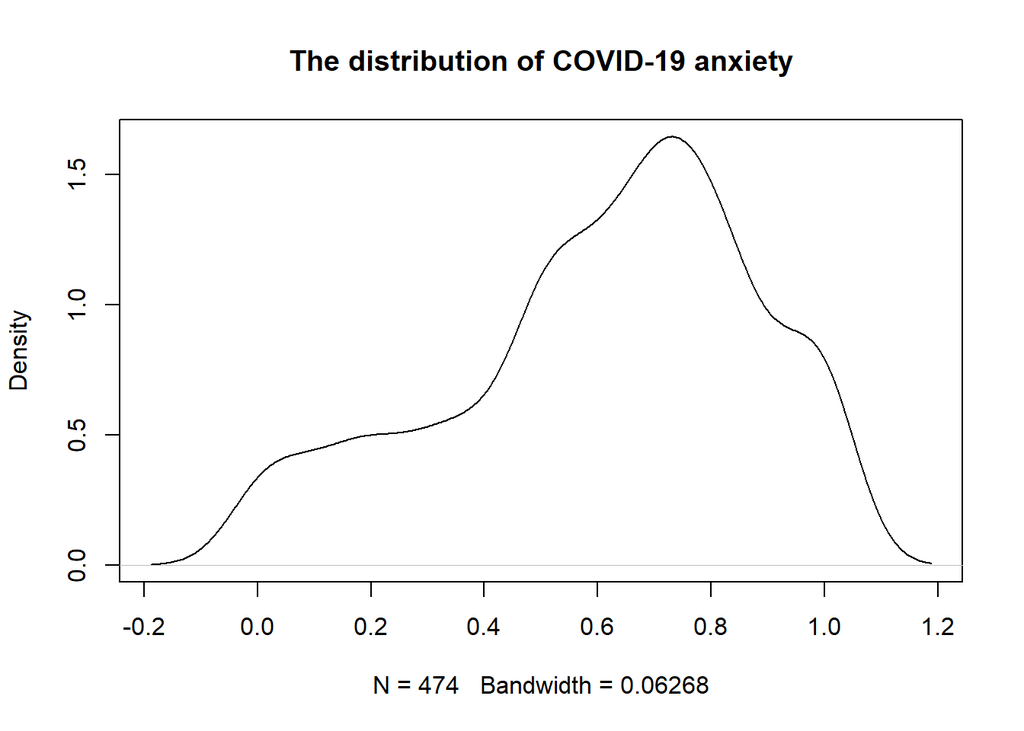

```r
# visualize the distribution of COVID-19 anxiety
plot(density(nocebo_1$c19_anxiety), main="The distribution of COVID-19 anxiety")
```

```r
# save the plot at the folder "figures" with the name of "COVID-19 anxiety"
png(file= here("figures","COVID-19 anxiety.png"), bg="transparent")
plot(density(nocebo_1$c19_anxiety), main="The distribution of COVID-19 anxiety")
dev.off()
```

```r
# check the numbers of participant had nocebo response to COVID-19
table(nocebo_1$sub_infected)
```

```
##
##   0   1
##  73 401
```

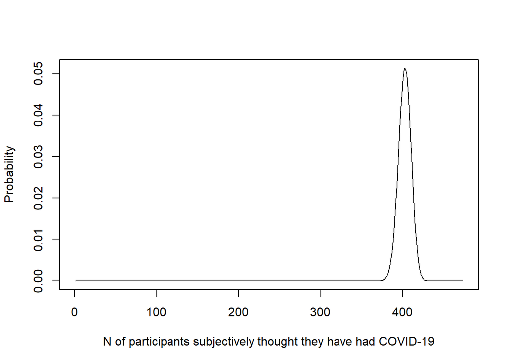

```r
# visualize the distribution of nocebo response to COVID-19 and save the plot at the folder "figures"
plot(1:474,dbinom(1:474,0.85, size=474),
     xlab='N of participants subjectively thought they have had COVID-19', ylab='Probability', type='l')
```

```r
# save the plot at the folder "figures" with the name of "Nocebo response to COVID-19"
png(file= here("figures","Nocebo response to COVID-19.png"), bg="transparent")
plot(1:474,dbinom(1:474,0.85, size=474),
     xlab='N of participants subjectively thought they have had COVID-19', ylab='Probability', type='l')
dev.off()
```

*<2>Bivariate plot*

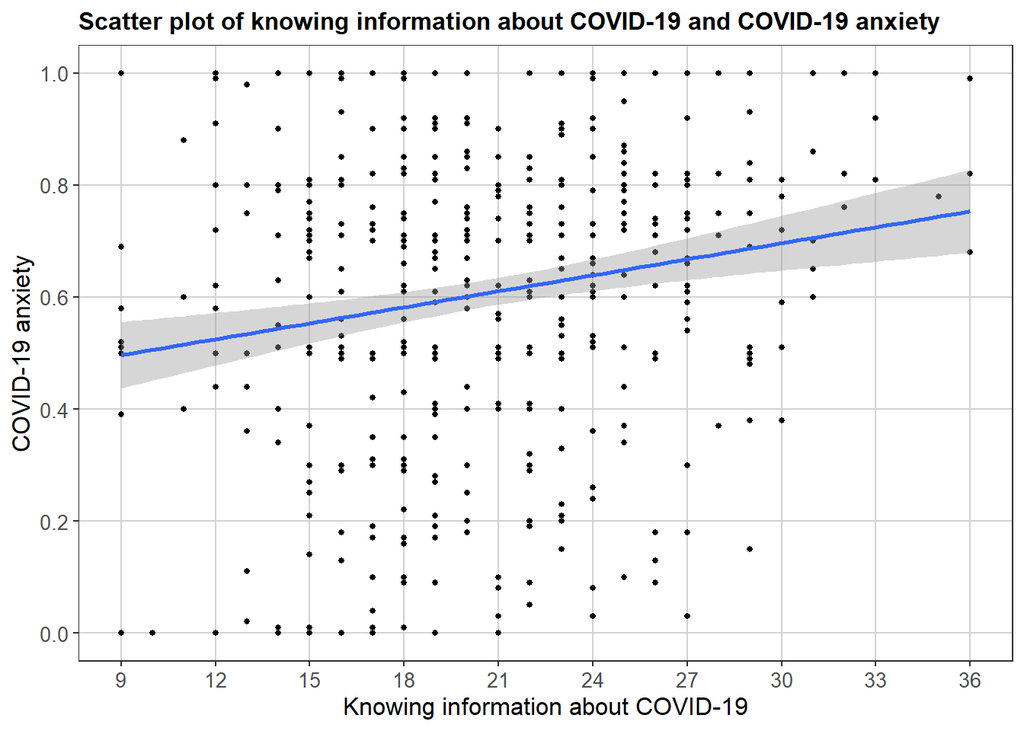

```r
# load the package used to draw a scatter plot
library(ggplot2)

# visualize the scatter plot of knowing information about COVID-19 and COVID-19 anxiety
fig1<-ggplot(nocebo_1, aes(x=total_info,y=c19_anxiety))+

  # make the points
  geom_point(size = 1)+

  # add the line of estimating the linear regression
  geom_smooth(method = lm, se = TRUE) +

  # add the title
  ggtitle("Scatter plot of knowing information about COVID-19 and COVID-19 anxiety")+

  # label the x axis and y axis
  labs(x="Knowing information about COVID-19",y="COVID-19 anxiety")+

  # set scale of x axis
  scale_x_continuous(limits=c(9,36),
                     breaks=seq(9,36, by = 3))+

  # set scale of y axis
  scale_y_continuous(limits=c(0,1),
                     breaks=seq(0,1, by = 0.20))+

  # set the theme
  theme_bw()+

  # set the elements
  theme(plot.title = element_text(size = 12, face = "bold"),
        panel.grid.major = element_line(colour = "lightgrey"),
        panel.grid.minor = element_blank(),
        axis.text = element_text(size = 10),
        axis.title = element_text(size = 12))

# save the scatter plot at the folder "figures" with the name of "scatter plot_1"
ggsave(plot =fig1, path = here("figures"), filename = "scatter plot_1.png")
# show the scatter plot
print(fig1)
```

# **4 Main Analysis**

## 4.1 Model 1: moderation of trusting in information sources and mediation of COVID-19 anxiety

### 4.1.0 Preparation for the interaction

```r
# calculate the interaction of knowing information about COVID-19 and trusting in information sources with zero-centered
nocebo_1 <- nocebo_1 %>%
  mutate(info_trust =
           ((info_1-mean(info_1))*(trust_1-mean(trust_1)) + (info_2-mean(info_2))*(trust_2-mean(trust_2))
            +(info_3-mean(info_3))*(trust_3-mean(trust_3))+ (info_4-mean(info_4))*(trust_4-mean(trust_4))
            +(info_5-mean(info_5))*(trust_5-mean(trust_5))+ (info_6-mean(info_6))*(trust_6-mean(trust_6))
            +(info_7-mean(info_7))*(trust_7-mean(trust_7))+ (info_8-mean(info_8))*(trust_8-mean(trust_8))
            +(info_9-mean(info_9))*(trust_9-mean(trust_9))))

# select the variables
nocebo_2 <- nocebo_1 %>%
  select(id, total_info, total_trust, info_trust, c19_anxiety, sub_infected)

# zero-centered the variables
nocebo_2$total_info_c <- scale(nocebo_2$total_info, center = TRUE, scale = FALSE)
nocebo_2$total_trust_c <- scale(nocebo_2$total_trust, center = TRUE, scale = FALSE)

# categorized the nocebo response to COVID-19
nocebo_2$sub_infected <- factor(nocebo_2$sub_infected, levels = c(0,1))

# randomly check 5 rows of the data
sample_n(nocebo_2,5)
```

```
##                                                                 id total_info
## 1 MmFkN2FlYmEtYWRkMy1iNWY2LWI1YmItOTlmY2YyZjYxMzRjM2EtMTYzMDE4Njk-         25
## 2                                                       1490628895         20
## 3 ZDZjNWU4MWUtNDhlNi0xN2QzLWZkMWYtZGZlZTZmZGE4Y2Q4M2EtMTYzMDE4Njk-         14
## 4 N2YyMmNhMTctYWY3Mi05MWI2LTU4MTYtZmQwOWQyOTZhOWUyM2EtMTYzMDE4Njk-         26
## 5                                                       1490694754         16
##   total_trust info_trust c19_anxiety sub_infected total_info_c total_trust_c
## 1          24   3.719752        0.77            1    4.2341772      1.270042
## 2          17   2.053085        0.71            1   -0.7658228     -5.729958
## 3          21   5.084731        0.79            0   -6.7658228     -1.729958
## 4          28   1.812579        0.80            1    5.2341772      5.270042
## 5          19   2.930722        0.85            0   -4.7658228     -3.729958
```

### 4.1.1 SEM model

```r
# load the package to analyze the path model
library(lavaan)
```

```r
model1 <-'
c19_anxiety ~ b1*total_info_c  + b2*total_trust_c + b3*info_trust
sub_infected~a1*total_info_c  + a2*total_trust_c + a3*info_trust + c*c19_anxiety

dir := a1+a2+a3
ind := (b1+b2+b3)*c
tot := dir + ind
'
fit1 <- sem(model1, ordered = c("sub_infected"), data = nocebo_2)
summary(fit1, fit.measures = TRUE)
```

```
## lavaan 0.6-9 ended normally after 32 iterations
##
##   Estimator                                       DWLS
##   Optimization method                           NLMINB
##   Number of model parameters                        10
##
##   Number of observations                           474
##
## Model Test User Model:
##                                               Standard      Robust
##   Test Statistic                                 0.000       0.000
##   Degrees of freedom                                 0           0
##
## Model Test Baseline Model:
##
##   Test statistic                                 2.532       2.532
##   Degrees of freedom                                 1           1
##   P-value                                        0.112       0.112
##   Scaling correction factor                                  1.000
##
## User Model versus Baseline Model:
##
##   Comparative Fit Index (CFI)                    1.000       1.000
##   Tucker-Lewis Index (TLI)                       1.000       1.000
##
##   Robust Comparative Fit Index (CFI)                            NA
##   Robust Tucker-Lewis Index (TLI)                               NA
##
## Root Mean Square Error of Approximation:
##
##   RMSEA                                          0.000       0.000
##   90 Percent confidence interval - lower         0.000       0.000
##   90 Percent confidence interval - upper         0.000       0.000
##   P-value RMSEA <= 0.05                             NA          NA
##
##   Robust RMSEA                                                  NA
##   90 Percent confidence interval - lower                     0.000
##   90 Percent confidence interval - upper                     0.000
##
## Standardized Root Mean Square Residual:
```

[output cut: 29 more lines]

```
##
## Variances:
##                    Estimate  Std.Err  z-value  P(>|z|)
##    .c19_anxiety       0.069    0.006   12.250    0.000
##    .sub_infected      0.989
##
## Scales y*:
##                    Estimate  Std.Err  z-value  P(>|z|)
##     sub_infected      1.000
##
## Defined Parameters:
##                    Estimate  Std.Err  z-value  P(>|z|)
##     dir               0.004    0.025    0.154    0.877
##     ind              -0.004    0.003   -1.337    0.181
##     tot              -0.001    0.025   -0.023    0.982
```

## 4.2 Model 2: moderation of knowing information from different sources and mediation of COVID-19 anxiety

```r
# select the variables
nocebo_3 <- nocebo_1 %>%
  select(id, c19_anxiety, sub_infected)

# calculate the sum of knowing information about COVID-19 from authority sources
nocebo_3$a_info = apply(nocebo_1[,7:9],1,sum)


# calculate the sum of knowing information about COVID-19 from non-authority sources
nocebo_3$na_info = apply(nocebo_1[,c(2:6,10)],1,sum)


# according to the mean, divide into two groups "0" and "1"
nocebo_3$a_info_c = ifelse(nocebo_3$a_info >= mean(nocebo_3$a_info), 1, 0)

nocebo_3$na_info_c = ifelse(nocebo_3$na_info >= mean(nocebo_3$na_info), 1, 0)


# interaction between the amount and sources of knowing information about COVID-19
nocebo_3$total_info_c = paste(nocebo_3$a_info_c, nocebo_3$na_info_c)

nocebo_3$total_info_1 = ifelse(nocebo_3$total_info_c == "0 1", 1, 0)

nocebo_3$total_info_2 = ifelse(nocebo_3$total_info_c == "1 0", 1, 0)

nocebo_3$total_info_3 = ifelse(nocebo_3$total_info_c == "1 1", 1, 0)

# categorized the nocebo response to COVID-19
nocebo_3$sub_infected <- factor(nocebo_3$sub_infected, levels = c(0,1))

# check the numbers of each group
table(apply(nocebo_3[,9:11],2,sum))
```

```
##
##  76  89 164
##   1   1   1
```

```r
# randomly check the 5 rows of the data
sample_n(nocebo_3,5)
```

```
##                                                                 id c19_anxiety
## 1 ZjMyMzhkZGMtOTA3MS03MTRmLTEyZGItYmEwOGNjODg4MjAwM2EtMTYzMDE4Njk-        0.82
## 2                                                       1490754182        1.00
## 3 NWU5YjIxYmMtOWY3OS0yMTljLWY4YmQtMTZiMDdlMDU5MjRhM2EtMTYzMDE4Njk-        0.00
## 4                                                       1775944259        0.52
## 5                                                       1466403020        0.71
##   sub_infected a_info na_info a_info_c na_info_c total_info_c total_info_1
## 1            1      9      18        1         1          1 1            0
## 2            1      6      21        1         1          1 1            0
## 3            1      5      12        0         0          0 0            0
## 4            1      6      18        1         1          1 1            0
## 5            1      8      15        1         1          1 1            0
##   total_info_2 total_info_3
## 1            0            1
## 2            0            1
## 3            0            0
## 4            0            1
## 5            0            1
```

```r
model2 <- '
c19_anxiety ~ b1*total_info_1 + b2*total_info_2 + b3*total_info_3
sub_infected~ a1*total_info_1 + a2*total_info_2 + a3*total_info_3 + c*c19_anxiety

dir := a1 + a2 + a3
ind := (b1+b2+b3)*c
tot := dir + ind
'
fit2 <- sem(model2, ordered = c("sub_infected"), data = nocebo_3)
summary(fit2, fit.measures = TRUE)
```

```
## lavaan 0.6-9 ended normally after 32 iterations
##
##   Estimator                                       DWLS
##   Optimization method                           NLMINB
##   Number of model parameters                        10
##
##   Number of observations                           474
##
## Model Test User Model:
##                                               Standard      Robust
##   Test Statistic                                 0.000       0.000
##   Degrees of freedom                                 0           0
##
## Model Test Baseline Model:
##
##   Test statistic                                 2.604       2.604
##   Degrees of freedom                                 1           1
##   P-value                                        0.107       0.107
##   Scaling correction factor                                  1.000
##
## User Model versus Baseline Model:
##
##   Comparative Fit Index (CFI)                    1.000       1.000
##   Tucker-Lewis Index (TLI)                       1.000       1.000
##
##   Robust Comparative Fit Index (CFI)                            NA
##   Robust Tucker-Lewis Index (TLI)                               NA
##
## Root Mean Square Error of Approximation:
##
##   RMSEA                                          0.000       0.000
##   90 Percent confidence interval - lower         0.000       0.000
##   90 Percent confidence interval - upper         0.000       0.000
##   P-value RMSEA <= 0.05                             NA          NA
##
##   Robust RMSEA                                                  NA
##   90 Percent confidence interval - lower                     0.000
##   90 Percent confidence interval - upper                     0.000
##
## Standardized Root Mean Square Residual:
```

[output cut: 29 more lines]

```
##
## Variances:
##                    Estimate  Std.Err  z-value  P(>|z|)
##    .c19_anxiety       0.070    0.006   12.331    0.000
##    .sub_infected      0.989
##
## Scales y*:
##                    Estimate  Std.Err  z-value  P(>|z|)
##     sub_infected      1.000
##
## Defined Parameters:
##                    Estimate  Std.Err  z-value  P(>|z|)
##     dir               1.076    0.466    2.309    0.021
##     ind              -0.131    0.086   -1.519    0.129
##     tot               0.945    0.460    2.055    0.040
```

# **5 Subsidiary analyses**

**adding the controls variables**

Model 3: moderation of trust in information sources and mediation of COVID-19 anxiety with control variables

```r
# add the control variables into the data
nocebo_2$age_cate <- nocebo_1$age_cate
nocebo_2$gad <- nocebo_1$gad
nocebo_2$health <- nocebo_1$health
nocebo_2$gender <- nocebo_1$gender
nocebo_2$income <- nocebo_1$income

# randomly check 5 rows of the data
sample_n(nocebo_2,5)
```

```
##                                                                 id total_info
## 1 MDcwZDMwYmMtOWYzYi02NDYyLWY4YmEtMDcyNjZiZmYwODdlM2EtMTYzMDE4Njk-         21
## 2                                                       1755184073         25
## 3                                                       1632769675         20
## 4                                                       1491783508         18
## 5                                                       1490721935         19
##   total_trust info_trust c19_anxiety sub_infected total_info_c total_trust_c
## 1          23   5.323128        0.79            0    0.2341772     0.2700422
## 2          18  -1.514425        0.44            1    4.2341772    -4.7299578
## 3          26  -1.575607        0.76            1   -0.7658228     3.2700422
## 4          21   1.605828        0.09            1   -2.7658228    -1.7299578
## 5          25   6.947600        0.50            1   -1.7658228     2.2700422
##   age_cate gad health gender income
## 1        6   0      1      0      1
## 2        2   1      1      1      1
## 3        2   0      0      1      2
## 4        4   0      1      0      5
## 5        6   0      0      1      2
```

```r
model3 <-'
c19_anxiety ~ b1*total_info_c  + b2*total_trust_c + b3*info_trust + age_cate + gender + income + health + gad
sub_infected~a1*total_info_c  + a2*total_trust_c + a3*info_trust + c*c19_anxiety + age_cate + gender + income + health + gad

dir := a1+a2+a3
ind := (b1+b2+b3)*c
tot := dir + ind
'
fit3 <- sem(model3, ordered = c("sub_infected"), data = nocebo_2)
summary(fit3, fit.measures = TRUE)
```

```
## lavaan 0.6-9 ended normally after 57 iterations
##
##   Estimator                                       DWLS
##   Optimization method                           NLMINB
##   Number of model parameters                        20
##
##   Number of observations                           474
##
## Model Test User Model:
##                                               Standard      Robust
##   Test Statistic                                 0.000       0.000
##   Degrees of freedom                                 0           0
##
## Model Test Baseline Model:
##
##   Test statistic                                 1.710       1.710
##   Degrees of freedom                                 1           1
##   P-value                                        0.191       0.191
##   Scaling correction factor                                  1.000
##
## User Model versus Baseline Model:
##
##   Comparative Fit Index (CFI)                    1.000       1.000
##   Tucker-Lewis Index (TLI)                       1.000       1.000
##
##   Robust Comparative Fit Index (CFI)                            NA
##   Robust Tucker-Lewis Index (TLI)                               NA
##
## Root Mean Square Error of Approximation:
##
##   RMSEA                                          0.000       0.000
##   90 Percent confidence interval - lower         0.000       0.000
##   90 Percent confidence interval - upper         0.000       0.000
##   P-value RMSEA <= 0.05                             NA          NA
##
##   Robust RMSEA                                                  NA
##   90 Percent confidence interval - lower                     0.000
##   90 Percent confidence interval - upper                     0.000
##
## Standardized Root Mean Square Residual:
```

[output cut: 39 more lines]

```
##
## Variances:
##                    Estimate  Std.Err  z-value  P(>|z|)
##    .c19_anxiety       0.064    0.005   12.295    0.000
##    .sub_infected      0.993
##
## Scales y*:
##                    Estimate  Std.Err  z-value  P(>|z|)
##     sub_infected      1.000
##
## Defined Parameters:
##                    Estimate  Std.Err  z-value  P(>|z|)
##     dir               0.001    0.026    0.058    0.954
##     ind              -0.003    0.003   -1.135    0.257
##     tot              -0.002    0.026   -0.070    0.944
```

Model 4: moderation of knowing information from different sources and mediation of COVID-19 anxiety with control variables

```r
# add the control variables into the data
nocebo_3$age_cate <- nocebo_1$age_cate
nocebo_3$gad <- nocebo_1$gad
nocebo_3$health <- nocebo_1$health
nocebo_3$gender <- nocebo_1$gender
nocebo_3$income <- nocebo_1$income

# randomly check 5 rows of the data
sample_n(nocebo_3,5)
```

```
##                                                                 id c19_anxiety
## 1                                                       1490709249        0.60
## 2 NTZlOWRlY2YtNWQwMS0yODg2LTY3Y2YtZTljMjgzMDNjYzE1M2EtMTYzMDE4Njk-        0.68
## 3                                                       1491764668        0.91
## 4                                                       1491783508        0.09
## 5                                                       1491500432        0.82
##   sub_infected a_info na_info a_info_c na_info_c total_info_c total_info_1
## 1            1      7      16        1         1          1 1            0
## 2            0      4      11        0         0          0 0            0
## 3            0      4      15        0         1          0 1            1
## 4            1      3      15        0         1          0 1            1
## 5            0     11      16        1         1          1 1            0
##   total_info_2 total_info_3 age_cate gad health gender income
## 1            0            1        5   1      1      1      5
## 2            0            0        6   0      1      0      1
## 3            0            0        6   0      1      1      3
## 4            0            0        4   0      1      0      5
## 5            0            1        6   1      0      0      2
```

```r
model4 <- '
c19_anxiety ~ b1*total_info_1 + b2*total_info_2 + b3*total_info_3 +  age_cate + gender + income + health + gad
sub_infected~ a1*total_info_1 + a2*total_info_2 + a3*total_info_3 + c*c19_anxiety + age_cate + gender + income + health + gad

dir := a1 + a2 + a3
ind := (b1+b2+b3)*c
tot := dir + ind
'
fit4 <- sem(model4, ordered = c("sub_infected"), data = nocebo_3)
summary(fit4, fit.measures = TRUE)
```

```
## lavaan 0.6-9 ended normally after 57 iterations
##
##   Estimator                                       DWLS
##   Optimization method                           NLMINB
##   Number of model parameters                        20
##
##   Number of observations                           474
##
## Model Test User Model:
##                                               Standard      Robust
##   Test Statistic                                 0.000       0.000
##   Degrees of freedom                                 0           0
##
## Model Test Baseline Model:
##
##   Test statistic                                 1.626       1.626
##   Degrees of freedom                                 1           1
##   P-value                                        0.202       0.202
##   Scaling correction factor                                  1.000
##
## User Model versus Baseline Model:
##
##   Comparative Fit Index (CFI)                    1.000       1.000
##   Tucker-Lewis Index (TLI)                       1.000       1.000
##
##   Robust Comparative Fit Index (CFI)                            NA
##   Robust Tucker-Lewis Index (TLI)                               NA
##
## Root Mean Square Error of Approximation:
##
##   RMSEA                                          0.000       0.000
##   90 Percent confidence interval - lower         0.000       0.000
##   90 Percent confidence interval - upper         0.000       0.000
##   P-value RMSEA <= 0.05                             NA          NA
##
##   Robust RMSEA                                                  NA
##   90 Percent confidence interval - lower                     0.000
##   90 Percent confidence interval - upper                     0.000
##
## Standardized Root Mean Square Residual:
```

[output cut: 39 more lines]

```
##
## Variances:
##                    Estimate  Std.Err  z-value  P(>|z|)
##    .c19_anxiety       0.064    0.005   12.511    0.000
##    .sub_infected      0.993
##
## Scales y*:
##                    Estimate  Std.Err  z-value  P(>|z|)
##     sub_infected      1.000
##
## Defined Parameters:
##                    Estimate  Std.Err  z-value  P(>|z|)
##     dir               1.013    0.500    2.027    0.043
##     ind              -0.112    0.091   -1.228    0.220
##     tot               0.901    0.492    1.833    0.067
```

### *References*

Kirill Müller (2020). here: A Simpler Way to Find Your Files. R package version 1.0.1. https://CRAN.R-project.org/package=here

Revelle W (2021). psych: Procedures for Psychological, Psychometric, and Personality Research. Northwestern University, Evanston, Illinois. R package version 2.1.6, https://CRAN.R-project.org/package=psych.

Wickham H, Averick M, Bryan J, Chang W, McGowan LD, François R, Grolemund G, Hayes A, Henry L, Hester J, Kuhn M, Pedersen TL, Miller E, Bache SM, Müller K, Ooms J, Robinson D, Seidel DP, Spinu V, Takahashi K, Vaughan D, Wilke C, Woo K, Yutani H (2019). “Welcome to the tidyverse.” Journal of Open Source Software, 4(43), 1686. doi: 10.21105/joss.01686.

Wickham, H. (2016). ggplot2: Elegant Graphics for Data Analysis. Springer-Verlag New York.

Yihui Xie (2021). knitr: A General-Purpose Package for Dynamic Report Generation in R. R package version 1.33.

Yves Rosseel (2012). lavaan: An R Package for Structural Equation Modeling. Journal of Statistical Software, 48(2), 1-36. URL https://www.jstatsoft.org/v48/i02/.